# **Finance & Data Analysis with R**

# **Individual Course Project**

## *Joaquin Arias*

**DISCLAIMER:** The following project assumes that the following libraries are already installed, if not please uncomment and run the following lines of code:

```r
# install.packages("tidyverse")
# install.packages(c("tidymodels", "randomForest", "doParallel", "torch", "caTools", "tabnet", "lime", "luz","reshape2","hmisc","smotefamily", "caret", "catboost","DMwR2","themis","recipes","tidymodels","pROC"))
#devtools::install_github("catboost/catboost", subdir = "catboost/R-package")
```

### Introduction

In the following project we are going to apply the knowledge gained on data science and machine learning using the programming language R and all the useful libraries that compose it. This is going to be done on the Credit Scoring dataset, this data was collected from the Taiwan Economic Journal from 1999 and 2009.It contains 95 features that detail the situationship of the different companies with multiple financial and operational metrics and indicators. The target variable is whether the company has filed for bankruptcy or not, indicated as a class label in the first column.

### Data Analysis

To start the exploratory data analysis we are going to load the data and the packages we expect to use.

```r
library(tidyverse)
library(dplyr)              # For data manipulation
library(ggplot2)            # For the plots
library(reshape2)           # For the correlation matrix
library(corrplot)
library(Hmisc)
library(scales)             # For percentage format
library(smotefamily)        # For unbalanced dataset treatment
library(caret)              # For ML tasks
# Machine Learning Models to use
library(catboost)
library(DMwR2)
library(themis)             # Provides step_smote for recipes
library(recipes)            # For pre-processing
library(tidymodels)         # For data splitting and modeling
library(pROC)
```

Loading the bankruptcy dataset and assigning it to the df variable:

```r
load("bankruptcy.RData") # Loading the file
df<-bankruptcy # Assigning it to the variable df for manipulation
rm(bankruptcy) # Removing the RData since we already have the data stored in df
```

We are going to analyze the dataframe and the characteristics of it:

```r
dim(df) # This command helps us measure the number of rows and columns in the dataset
```

```
[1] 6819   96
```

As specified before, our dataset contains 95 features and 1 output variable. In rows, we have the information of 6.819 companies that either went bankrupt or not.

```r
head(df) # Display the first 5 rows of our dataframe to understand how is the information given and which variables we have in it.
```

| Bankrupt? | ROA(C) before interest and depreciation before interest | ROA(A) before interest and % after tax | ROA(B) before interest and depreciation after tax | Operating Gross Margin | Realized Sales Gross Margin | Operating Profit Rate | Pre-tax net Interest Rate | After-tax net Interest Rate | Non-industry income and expenditure/revenue | Continuous interest rate (after tax) | Operating Expense Rate | Research and development expense rate | Cash flow rate | Interest-bearing debt interest rate | Tax rate (A) | Net Value Per Share (B) | Net Value Per Share (A) | Net Value Per Share (C) | Persistent EPS in the Last Four Seasons | Cash Flow Per Share | Revenue Per Share (Yuan ¥) | Operating Profit Per Share (Yuan ¥) | Per Share Net profit before tax (Yuan ¥) | Realized Sales Gross Profit Growth Rate | Operating Profit Growth Rate | After-tax Net Profit Growth Rate | Regular Net Profit Growth Rate | Continuous Net Profit Growth Rate | Total Asset Growth Rate | … |
| --- | --- | --- | --- | --- | --- | --- | --- | --- | --- | --- | --- | --- | --- | --- | --- | --- | --- | --- | --- | --- | --- | --- | --- | --- | --- | --- | --- | --- | --- | --- |
| 1 | 0.3705943 | 0.4243894 | 0.4057498 | 0.6014572 | 0.6014572 | 0.9989692 | 0.7968871 | 0.8088094 | 0.3026464 | 0.7809849 | 1.256969e-04 | 0 | 0.4581431 | 0.0007250725 | 0 | 0.1479499 | 0.1479499 | 0.1479499 | 0.1691406 | 0.3116644 | 0.017559780 | 0.09592053 | 0.1387362 | 0.02210228 | 0.8481950 | 0.6889795 | 0.6889795 | 0.2175354 | 4.98e+09 | … |
| 1 | 0.4642909 | 0.5382141 | 0.5167300 | 0.6102351 | 0.6102351 | 0.9989460 | 0.7973802 | 0.8093007 | 0.3035564 | 0.7815060 | 2.897851e-04 | 0 | 0.4618673 | 0.0006470647 | 0 | 0.1822511 | 0.1822511 | 0.1822511 | 0.2089439 | 0.3181368 | 0.021144335 | 0.09372201 | 0.1699179 | 0.02208017 | 0.8480879 | 0.6896929 | 0.6897017 | 0.2176196 | 6.11e+09 | … |
| 1 | 0.4260713 | 0.4990188 | 0.4722951 | 0.6014500 | 0.6013635 | 0.9988574 | 0.7964034 | 0.8083875 | 0.3020352 | 0.7802839 | 2.361297e-04 | 25500000 | 0.4585206 | 0.0007900790 | 0 | 0.1779107 | 0.1779107 | 0.1937129 | 0.1805805 | 0.3071019 | 0.005944008 | 0.09233776 | 0.1428033 | 0.02276010 | 0.8480940 | 0.6894627 | 0.6894697 | 0.2176013 | 7.28e+09 | … |
| 1 | 0.3998440 | 0.4512647 | 0.4577333 | 0.5835411 | 0.5835411 | 0.9986997 | 0.7969670 | 0.8089656 | 0.3033495 | 0.7812410 | 1.078888e-04 | 0 | 0.4657054 | 0.0004490449 | 0 | 0.1541865 | 0.1541865 | 0.1541865 | 0.1937222 | 0.3216736 | 0.014368468 | 0.07776240 | 0.1486028 | 0.02204607 | 0.8480055 | 0.6891095 | 0.6891095 | 0.2175682 | 4.88e+09 | … |
| 1 | 0.4650222 | 0.5384322 | 0.5222978 | 0.5987835 | 0.5987835 | 0.9989731 | 0.7973661 | 0.8093037 | 0.3034750 | 0.7815500 | 7.890000e+09 | 0 | 0.4627463 | 0.0006860686 | 0 | 0.1675024 | 0.1675024 | 0.1675024 | 0.2125366 | 0.3191625 | 0.029689792 | 0.09689765 | 0.1684115 | 0.02209591 | 0.8482582 | 0.6896969 | 0.6896969 | 0.2176256 | 5.51e+09 | … |
| 1 | 0.3886803 | 0.4151766 | 0.4191338 | 0.5901714 | 0.5902507 | 0.9987581 | 0.7969032 | 0.8087706 | 0.3031158 | 0.7810691 | 1.571500e-04 | 0 | 0.4658615 | 0.0007160716 | 0 | 0.1555771 | 0.1555771 | 0.1555771 | 0.1744351 | 0.3253873 | 0.018104270 | 0.07808810 | 0.1388115 | 0.02156494 | 0.8479828 | 0.6891051 | 0.6891775 | 0.2175664 | 6.08e+08 | … |

Now its easy to visualize the 95 financial and performance variables that are given in our dataset. The indicators belong to different categories that help understand the situation of a company:

- Profitability
- Liquidity
- Leverage
- Efficiency
- Growth indicators

Now we are going to explore the structure and the datatype of all variables to understand how the following steps need to be performed

```r
str(df)    # This function will provide the structure and the datatype of each variable
```

```
spc_tbl_ [6,819 × 96] (S3: spec_tbl_df/tbl_df/tbl/data.frame)
 $ Bankrupt?                                              : num [1:6819] 1 1 1 1 1 1 0 0 0 0 ...
 $ ROA(C) before interest and depreciation before interest: num [1:6819] 0.371 0.464 0.426 0.4 0.465 ...
 $ ROA(A) before interest and % after tax                 : num [1:6819] 0.424 0.538 0.499 0.451 0.538 ...
 $ ROA(B) before interest and depreciation after tax      : num [1:6819] 0.406 0.517 0.472 0.458 0.522 ...
 $ Operating Gross Margin                                 : num [1:6819] 0.601 0.61 0.601 0.584 0.599 ...
 $ Realized Sales Gross Margin                            : num [1:6819] 0.601 0.61 0.601 0.584 0.599 ...
 $ Operating Profit Rate                                  : num [1:6819] 0.999 0.999 0.999 0.999 0.999 ...
 $ Pre-tax net Interest Rate                              : num [1:6819] 0.797 0.797 0.796 0.797 0.797 ...
 $ After-tax net Interest Rate                            : num [1:6819] 0.809 0.809 0.808 0.809 0.809 ...
 $ Non-industry income and expenditure/revenue            : num [1:6819] 0.303 0.304 0.302 0.303 0.303 ...
 $ Continuous interest rate (after tax)                   : num [1:6819] 0.781 0.782 0.78 0.781 0.782 ...
 $ Operating Expense Rate                                 : num [1:6819] 1.26e-04 2.90e-04 2.36e-04 1.08e-04 7.89e+09 ...
 $ Research and development expense rate                  : num [1:6819] 0.00 0.00 2.55e+07 0.00 0.00 0.00 7.30e+08 5.09e+07 0.00 0.00 ...
 $ Cash flow rate                                         : num [1:6819] 0.458 0.462 0.459 0.466 0.463 ...
 $ Interest-bearing debt interest rate                    : num [1:6819] 0.000725 0.000647 0.00079 0.000449 0.000686 ...
 $ Tax rate (A)                                           : num [1:6819] 0 0 0 0 0 ...
 $ Net Value Per Share (B)                                : num [1:6819] 0.148 0.182 0.178 0.154 0.168 ...
 $ Net Value Per Share (A)                                : num [1:6819] 0.148 0.182 0.178 0.154 0.168 ...
 $ Net Value Per Share (C)                                : num [1:6819] 0.148 0.182 0.194 0.154 0.168 ...
 $ Persistent EPS in the Last Four Seasons                : num [1:6819] 0.169 0.209 0.181 0.194 0.213 ...
 $ Cash Flow Per Share                                    : num [1:6819] 0.312 0.318 0.307 0.322 0.319 ...
 $ Revenue Per Share (Yuan ¥)                             : num [1:6819] 0.01756 0.02114 0.00594 0.01437 0.02969 ...
 $ Operating Profit Per Share (Yuan ¥)                    : num [1:6819] 0.0959 0.0937 0.0923 0.0778 0.0969 ...
 $ Per Share Net profit before tax (Yuan ¥)               : num [1:6819] 0.139 0.17 0.143 0.149 0.168 ...
 $ Realized Sales Gross Profit Growth Rate                : num [1:6819] 0.0221 0.0221 0.0228 0.022 0.0221 ...
 $ Operating Profit Growth Rate                           : num [1:6819] 0.848 0.848 0.848 0.848 0.848 ...
 $ After-tax Net Profit Growth Rate                       : num [1:6819] 0.689 0.69 0.689 0.689 0.69 ...
 $ Regular Net Profit Growth Rate                         : num [1:6819] 0.689 0.69 0.689 0.689 0.69 ...
 $ Continuous Net Profit Growth Rate                      : num [1:6819] 0.218 0.218 0.218 0.218 0.218 ...
 $ Total Asset Growth Rate                                : num [1:6819] 4.98e+09 6.11e+09 7.28e+09 4.88e+09 5.51e+09 6.08e+08 5.72e+09 6.63e+09 6.89e+09 5.55e+09 ...
 $ Net Value Growth Rate                                  : num [1:6819] 0.000327 0.000443 0.000396 0.000382 0.000439 ...
 $ Total Asset Return Growth Rate Ratio                   : num [1:6819] 0.263 0.265 0.264 0.263 0.265 ...
 $ Cash Reinvestment %                                    : num [1:6819] 0.364 0.377 0.369 0.384 0.38 ...
 $ Current Ratio                                          : num [1:6819] 0.00226 0.00602 0.01154 0.00419 0.00602 ...
 $ Quick Ratio                                            : num [1:6819] 0.00121 0.00404 0.00535 0.0029 0.00373 ...
 $ Interest Expense Ratio                                 : num [1:6819] 0.63 0.635 0.63 0.63 0.636 ...
 $ Total debt/Total net worth                             : num [1:6819] 0.02127 0.0125 0.02125 0.00957 0.00515 ...
 $ Debt ratio %                                           : num [1:6819] 0.208 0.171 0.208 0.151 0.107 ...
 $ Net worth/Assets                                       : num [1:6819] 0.792 0.829 0.792 0.849 0.893 ...
```

[output cut: 142 more lines]

```
  ..   `Cash Flow to Equity` = col_double(),
  ..   `Current Liability to Current Assets` = col_double(),
  ..   `Liability-Assets Flag` = col_double(),
  ..   `Net Income to Total Assets` = col_double(),
  ..   `Total assets to GNP price` = col_double(),
  ..   `No-credit Interval` = col_double(),
  ..   `Gross Profit to Sales` = col_double(),
  ..   `Net Income to Stockholder's Equity` = col_double(),
  ..   `Liability to Equity` = col_double(),
  ..   `Degree of Financial Leverage (DFL)` = col_double(),
  ..   `Interest Coverage Ratio (Interest expense to EBIT)` = col_double(),
  ..   `Net Income Flag` = col_double(),
  ..   `Equity to Liability` = col_double()
  .. )
 - attr(*, "problems")=<externalptr>
```

All of our columns are numeric, which indicates that this dataset is suitable and might be ready for the financial analysis and machine learning tasks. The only categorical variable is the target, whether the company went bankrupt or not.

We want to also check if there exist missing values that may need treatment or imputation

```r
any(is.na(df)) # Checking if there are missing values in the whole dataset
```

```
[1] FALSE
```

```r
sum(is.na(df)) # Summing the total number of missing values
```

```
[1] 0
```

Without missing values we can proceed to perform statistical analysis on each variable to identify variable trends and outliers.

We proceed to analyze all the statistics related to each variable of our dataset:

```r
summary(df)
```

```
   Bankrupt?       ROA(C) before interest and depreciation before interest
 Min.   :0.00000   Min.   :0.0000
 1st Qu.:0.00000   1st Qu.:0.4765
 Median :0.00000   Median :0.5027
 Mean   :0.03226   Mean   :0.5052
 3rd Qu.:0.00000   3rd Qu.:0.5356
 Max.   :1.00000   Max.   :1.0000
 ROA(A) before interest and % after tax ROA(B) before interest and depreciation after tax
 Min.   :0.0000                         Min.   :0.0000
 1st Qu.:0.5355                         1st Qu.:0.5273
 Median :0.5598                         Median :0.5523
 Mean   :0.5586                         Mean   :0.5536
 3rd Qu.:0.5892                         3rd Qu.:0.5841
 Max.   :1.0000                         Max.   :1.0000
 Operating Gross Margin Realized Sales Gross Margin Operating Profit Rate
 Min.   :0.0000         Min.   :0.0000              Min.   :0.0000
 1st Qu.:0.6004         1st Qu.:0.6004              1st Qu.:0.9990
 Median :0.6060         Median :0.6060              Median :0.9990
 Mean   :0.6079         Mean   :0.6079              Mean   :0.9988
 3rd Qu.:0.6139         3rd Qu.:0.6138              3rd Qu.:0.9991
 Max.   :1.0000         Max.   :1.0000              Max.   :1.0000
 Pre-tax net Interest Rate After-tax net Interest Rate
 Min.   :0.0000            Min.   :0.0000
 1st Qu.:0.7974            1st Qu.:0.8093
 Median :0.7975            Median :0.8094
 Mean   :0.7972            Mean   :0.8091
 3rd Qu.:0.7976            3rd Qu.:0.8095
 Max.   :1.0000            Max.   :1.0000
 Non-industry income and expenditure/revenue Continuous interest rate (after tax)
 Min.   :0.0000                              Min.   :0.0000
 1st Qu.:0.3035                              1st Qu.:0.7816
 Median :0.3035                              Median :0.7816
 Mean   :0.3036                              Mean   :0.7814
 3rd Qu.:0.3036                              3rd Qu.:0.7817
 Max.   :1.0000                              Max.   :1.0000
 Operating Expense Rate Research and development expense rate Cash flow rate
 Min.   :0.000e+00      Min.   :0.00e+00                      Min.   :0.0000
 1st Qu.:0.000e+00      1st Qu.:0.00e+00                      1st Qu.:0.4616
 Median :0.000e+00      Median :5.09e+08                      Median :0.4651
 Mean   :1.995e+09      Mean   :1.95e+09                      Mean   :0.4674
```

[output cut: 183 more lines]

```
 Max.   :9.820e+09         Max.   :1.0000     Max.   :1.0000
 Net Income to Stockholder's Equity Liability to Equity Degree of Financial Leverage (DFL)
 Min.   :0.0000                     Min.   :0.0000      Min.   :0.00000
 1st Qu.:0.8401                     1st Qu.:0.2769      1st Qu.:0.02679
 Median :0.8412                     Median :0.2788      Median :0.02681
 Mean   :0.8404                     Mean   :0.2804      Mean   :0.02754
 3rd Qu.:0.8424                     3rd Qu.:0.2814      3rd Qu.:0.02691
 Max.   :1.0000                     Max.   :1.0000      Max.   :1.00000
 Interest Coverage Ratio (Interest expense to EBIT) Net Income Flag Equity to Liability
 Min.   :0.0000                                     Min.   :1       Min.   :0.00000
 1st Qu.:0.5652                                     1st Qu.:1       1st Qu.:0.02448
 Median :0.5653                                     Median :1       Median :0.03380
 Mean   :0.5654                                     Mean   :1       Mean   :0.04758
 3rd Qu.:0.5657                                     3rd Qu.:1       3rd Qu.:0.05284
 Max.   :1.0000                                     Max.   :1       Max.   :1.00000
```

The dataset contains multiple numeric variables with a mix of ratios that go from 0 to 1 and larger metrics. The target variable *Bankrupt?* is a binary where 0 represents non bankruptcy and 1 represents bankrupt. Given that the mean is 0.03, we can conclude that most of the companies are not bankrupt. This results in an imbalanced dataset which will require attention when applying the classification model to avoid performance issues.

The variable *Net Income Flag* contains a unique value throughout the different companies, so we are going to remove it.

```r
df <- df |> select(-`Net Income Flag`)
```

Variables like *Interest-bearing debt interest rate*, *Inventory Turnover Rate* and *Revenue per Share* have extreme values and may need data scaling.

### Pivot Tables

First, we are going to create pivot tables that compare the bankruptcy rate with different financial metrics divided by 4 quantiles. This will let us know how the financial performance relates with bankruptcy and we are going to gain a superficial understanding of the most important features for bankruptcy.

**Bankruptcy Rate by ROA (A) Quantiles:**

```r
df |>
  mutate(ROA_A_Quantile = ntile(`ROA(A) before interest and % after tax`, 4)) |> # Create 4 Quantiles based on ROA A
  group_by(ROA_A_Quantile) |>
  summarise(Bankruptcy_Rate = mean(`Bankrupt?`, na.rm = TRUE)) |> # Summarise them by the average of the bankruptcy rate
  arrange(ROA_A_Quantile)
```

| ROA_A_Quantile | Bankruptcy_Rate |
| --- | --- |
| 1 | 0.101466276 |
| 2 | 0.019941349 |
| 3 | 0.007624633 |
| 4 | 0.000000000 |

**Interpretation:** Companies in the lowest quantile of ROA have the highest bankruptcy rate. As the ROA increases the bankruptcy decreases sharply and reches 0 in the highest quantile. This is a proof that the return on assets is a critical predictor of bankruptcy and that a higher ROA can translate into a reduction in the risk of bankruptcy. ROA (A) was used as it is directly tied with to the profitability and represents the company ability to generate profits from their assets.

**Bankruptcy Rate by Operating Gross Margin Quantiles:**

```r
df |>
  mutate(Operating_Gross_Margin_Quantile = ntile(`Operating Gross Margin`, 4)) |> # Create quartiles
  group_by(Operating_Gross_Margin_Quantile) |>
  summarise(Bankruptcy_Rate = mean(`Bankrupt?`, na.rm = TRUE)) |>       # Calculate bankruptcy rate for each quantile
  arrange(Operating_Gross_Margin_Quantile)
```

| Operating_Gross_Margin_Quantile | Bankruptcy_Rate |
| --- | --- |
| 1 | 0.07917889 |
| 2 | 0.02697947 |
| 3 | 0.01173021 |
| 4 | 0.01115023 |

```r
NA
```

**Interpretation:** Companies that have lower operating gross margin can be flagged for potential instability due to weaker operational efficiency.

**Bankruptcy Rate by Liability to Equity Quantiles:**

```r
df |>
  mutate(Liability_Equity_Quantile = ntile(`Liability to Equity`, 4)) |> # Create quartiles
  group_by(Liability_Equity_Quantile) |>
  summarise(Bankruptcy_Rate = mean(`Bankrupt?`, na.rm = TRUE)) |>       # Calculate bankruptcy rate
  arrange(Liability_Equity_Quantile)
```

| Liability_Equity_Quantile | Bankruptcy_Rate |
| --- | --- |
| 1 | 0.007038123 |
| 2 | 0.005865103 |
| 3 | 0.015249267 |
| 4 | 0.100938967 |

**Interpretation:** The pivot table obtained shows us that the companies with lower debt compared to their own resources have a very low risk of bankruptcy. As their debt increases the risk of bankruptcy also does.

**Bankruptcy Rate by Interest Coverage Ratio Quantiles:**

```r
df |>
  mutate(Interest_Coverage_Quantile = ntile(`Interest Coverage Ratio (Interest expense to EBIT)`, 4)) |> # Create quartiles
  group_by(Interest_Coverage_Quantile) |>
  summarise(Bankruptcy_Rate = mean(`Bankrupt?`, na.rm = TRUE)) |>                                         # Calculate bankruptcy rate
  arrange(Interest_Coverage_Quantile)
```

| Interest_Coverage_Quantile | Bankruptcy_Rate |
| --- | --- |
| 1 | 0.096187683 |
| 2 | 0.000000000 |
| 3 | 0.002346041 |
| 4 | 0.030516432 |

**Interpretation:** It is noteworthy that the pivot table reveals no clear trend of increasing or decreasing bankruptcy risk as we move across the quantiles in this case. In this case we see that the companies who struggle to pay interests on their debt are much more likely to go bankrupt. Companies that have a moderate ability to cover the interest show no risk of bankruptcy but companies with high coverage still face some risk of bankruptcy, but lower than those in Q1.

**Bankruptcy Rate by Inventory Turnover Rate Quantiles:**

```r
df |>
  mutate(Inventory_Turnover_Quantile = ntile(`Inventory Turnover Rate (times)`, 4)) |> # Create quartiles
  group_by(Inventory_Turnover_Quantile) |>
  summarise(Bankruptcy_Rate = mean(`Bankrupt?`, na.rm = TRUE)) |>                     # Calculate bankruptcy rate
  arrange(Inventory_Turnover_Quantile)
```

| Inventory_Turnover_Quantile | Bankruptcy_Rate |
| --- | --- |
| 1 | 0.02815249 |
| 2 | 0.02580645 |
| 3 | 0.04633431 |
| 4 | 0.02875587 |

**Interpretation:** Companies with mid level inventory turnover face a slightly higher bankruptcy risk. However the risk is relatively stable for those with very low or very high turnover and theres no clear upward or downward trend.

**Bankruptcy Rate by Cash Flow to Liability:**

```r
df |>
  mutate(Cash_Flow_Liability_Quantile = ntile(`Cash Flow to Liability`, 4)) |> # Create quartiles
  group_by(Cash_Flow_Liability_Quantile) |>                                   #
  summarise(Bankruptcy_Rate = mean(`Bankrupt?`, na.rm = TRUE)) |>             # Calculate bankruptcy rate
  arrange(Cash_Flow_Liability_Quantile)
```

| Cash_Flow_Liability_Quantile | Bankruptcy_Rate |
| --- | --- |
| 1 | 0.029325513 |
| 2 | 0.072727273 |
| 3 | 0.022287390 |
| 4 | 0.004694836 |

**Interpretation:** Bankruptcy risk is the highest in Q2, moderate in Q1 and Q3 and the lowest in Quantile 4. This highlights the critical role of mantaining an adequate liquidity to cover liabilities.

**Aggregated Metrics by Bankruptcy Status:**

```r
metrics <- c(
  "Net Income to Total Assets",
  "Gross Profit to Sales",
  "Operating Profit Rate",
  "Current Ratio",
  "Quick Ratio",
  "Cash Flow to Liability",
  "Debt ratio %",
  "Liability to Equity",
  "Interest Coverage Ratio (Interest expense to EBIT)",
  "Inventory Turnover Rate (times)",
  "Accounts Receivable Turnover",
  "Total Asset Turnover",
  "Operating Profit Growth Rate",
  "Net Value Growth Rate",
  "Total Asset Growth Rate",
  "Cash Flow Per Share",
  "Cash Flow to Sales",
  "CFO to Assets"
) # Create a list of the key metrics to aggregate and that we are going to analyze searching for meaningful information

# Calculate the aggregated metrics and the pivot table
df |>
  group_by(`Bankrupt?`) |>
  summarise(across(all_of(metrics), mean, na.rm = TRUE))
```

| Bankrupt? | Net Income to Total Assets | Gross Profit to Sales | Operating Profit Rate | Current Ratio | Quick Ratio | Cash Flow to Liability | Debt ratio % | Liability to Equity | Interest Coverage Ratio (Interest expense to EBIT) | Inventory Turnover Rate (times) | Accounts Receivable Turnover | Total Asset Turnover | Operating Profit Growth Rate | Net Value Growth Rate | Total Asset Growth Rate | Cash Flow Per Share | Cash Flow to Sales | CFO to Assets |
| --- | --- | --- | --- | --- | --- | --- | --- | --- | --- | --- | --- | --- | --- | --- | --- | --- | --- | --- |
| 0 | 0.8100831 | 0.6082556 | 0.9987557 | 4.167298e+05 | 7257160 | 0.4620850 | 0.1107144 | 0.2799247 | 0.5653712 | 2149921928 | 13031217 | 0.1428598 | 0.8480098 | 204576.5 | 5531602816 | 0.3237312 | 0.6715300 | 0.5946487 |
| 1 | 0.7380835 | 0.5986686 | 0.9987388 | 7.237612e-03 | 41954545 | 0.4547777 | 0.1870470 | 0.2935778 | 0.5649592 | 2124633636 | 5545455 | 0.1039866 | 0.8470868 | 42409090.9 | 4803016818 | 0.3160059 | 0.6715553 | 0.5564115 |

**Interpretation:**

Important Observations and Results:

- Companies that manage their money well (pay bills, collect payments and keep debt low) are much less likely to fail.
- Companies with too much debt or inefficient use of resources are at greater risk of bankruptcy.
- Surprisingly, rapid growth in equity can signal risky behavior and increase financial trouble.

**Growth Rate by Financial Ratios:**

```r
df |>
  mutate(Growth_Rate_Quantile = ntile(`Total Asset Growth Rate`, 4)) |> # Create quantiles for growth rate
  group_by(Growth_Rate_Quantile) |>
  summarise(across(c(`ROA(A) before interest and % after tax`, `Debt ratio %`, `Current Ratio`, `Quick Ratio`),
                   mean, na.rm = TRUE)) |> # Calculate mean for selected financial ratios
  arrange(Growth_Rate_Quantile)
```

| Growth_Rate_Quantile | ROA(A) before interest and % after tax | Debt ratio % | Current Ratio | Quick Ratio |
| --- | --- | --- | --- | --- |
| 1 | 0.5569409 | 0.1198497 | 1.532801e-02 | 10645161 |
| 2 | 0.5306954 | 0.1114289 | 1.592981e-02 | 15982405 |
| 3 | 0.5611988 | 0.1079639 | 1.612903e+06 | 4826979 |
| 4 | 0.5856804 | 0.1134659 | 1.467264e-02 | 2048122 |

```r
NA
```

**Interpretation:**

- Firms with higher growth rates tend to generate better returns on their assets, indicating a correlation between growth and profitability.
- Growth rates don’t seem to significantly affect how much debt companies carry relative to their total assets. This suggests that firms across all growth levels are leveraging their financial resources in a similar manner.
- Companies with moderate growth may strike a balance between growth and maintaining sufficient liquidity, avoiding excessive risk-taking.
- Faster-growing companies may prioritize easily accessible liquid assets, ensuring operational flexibility as they expand.
- While growth does not drastically affect debt ratios, its impact on profitability and liquidity highlights potential areas of risk or stability.

**Leverage and Liquidity Insights:**

```r
df |>
  mutate(Leverage_Quantile = ntile(`Liability to Equity`, 4)) |> # Create quantiles for leverage
  group_by(Leverage_Quantile) |>
  summarise(across(c(`Current Ratio`, `Quick Ratio`, `Cash Flow to Liability`),
                   mean, na.rm = TRUE)) |> # Calculate mean for liquidity metrics
  arrange(Leverage_Quantile)
```

| Leverage_Quantile | Current Ratio | Quick Ratio | Cash Flow to Liability |
| --- | --- | --- | --- |
| 1 | 1.612903e+06 | 2.338765e-02 | 0.4658109 |
| 2 | 1.300806e-02 | 2.815249e+06 | 0.4614991 |
| 3 | 9.883908e-03 | 6.475073e+06 | 0.4603654 |
| 4 | 7.637409e-03 | 2.422535e+07 | 0.4597203 |

**Interpretation:**

- Firms with lower leverage are significantly more equipped to handle short-term financial obligations due to better liquidity.
- As leverage increases, companies sacrifice liquidity, making them more vulnerable to financial distress.
- Cash flow efficiency relative to liabilities appears unaffected by leverage levels, suggesting other factors may play a larger role in cash flow management.

### GGPlots

We are going to plot some variables to have a visual representation and understand their behavior.

**Proportion of bankrupt and non-bankrupt companies:**

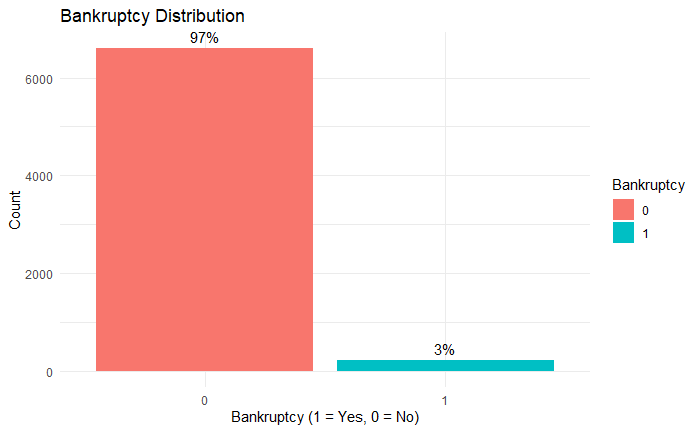

```r
ggplot(df, aes(x = as.factor(`Bankrupt?`), fill = as.factor(`Bankrupt?`))) +
  geom_bar() +
  geom_text(
    stat = "count",
    aes(label = scales::percent(..count.. / sum(..count..))),
    vjust = -0.5
  ) +
  labs(
    title = "Bankruptcy Distribution",
    x = "Bankruptcy (1 = Yes, 0 = No)",
    y = "Count",
    fill = "Bankruptcy"
  ) +
  theme_minimal()
```

**Interpretation:** The graph confirms what we have seen before, the target of the dataset is unbalanced and we are going to need to work on this for the model.

**Correlation Matrix:**

```r
# Compute Spearman correlation matrix and p-values
correlation_results <- Hmisc::rcorr(as.matrix(df[sapply(df, is.numeric)]), type = "spearman")
cor_matrix <- correlation_results$r
p_matrix <- correlation_results$P

# Filter non-significant correlations
cor_matrix[p_matrix >= 0.05] <- NA

# Melt the correlation matrix
melted_corr <- melt(cor_matrix, na.rm = TRUE)

# Create the heatmap
heatmap_plot <- ggplot(melted_corr, aes(x = Var1, y = Var2, fill = value)) +
  geom_tile(color = "white") +
  scale_fill_distiller(palette = "RdBu", direction = -1, limits = c(-1, 1), na.value = "grey90") +
  labs(
    title = "Spearman Correlation Heatmap (Significant Only)",
    x = NULL,
    y = NULL,
    fill = "Correlation"
  ) +
  theme_minimal() +
  theme(
    axis.text.x = element_text(angle = 90, hjust = 1, size = 10, margin = ggplot2::margin(t = 10)),
    axis.text.y = element_text(size = 10, margin = ggplot2::margin(r = 10)),
    plot.title = element_text(hjust = 0.5, face = "bold", size = 14),
    plot.margin = ggplot2::margin(t = 20, r = 20, b = 20, l = 20),
    panel.grid.major = element_blank(),
    panel.grid.minor = element_blank()
  )

# Save the heatmap
ggsave(
  filename = "correlation_heatmap_spaced_labels.png",
  plot = heatmap_plot,
  width = 20,
  height = 15,
  dpi = 300
)
```

- Interest coverage ratio (-)
- Cash flow metrics (-)
- Debt ratios (+)
- Operating profit margins (-)

And the most predictive metrics appear to be the following:

- ROAA/ROAE (Return on Assets and Equity)
- Debt coverage ratios
- Cash flow to liability ratios
- Working capital metrics

**BoxPlots**

**Bankrupt Vs. Net Income to Total Assets:**

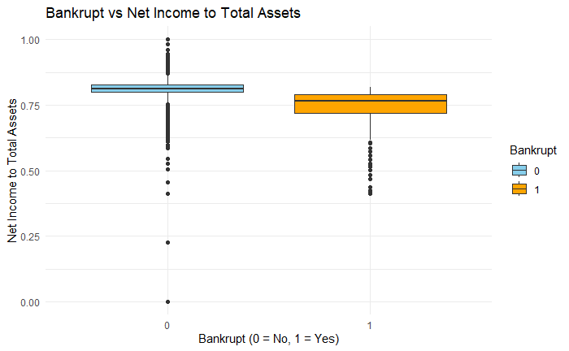

```r
ggplot(df, aes(x = as.factor(`Bankrupt?`), y = `Net Income to Total Assets`, fill = as.factor(`Bankrupt?`))) +
  geom_boxplot() +
  labs(title = "Bankrupt vs Net Income to Total Assets",
       x = "Bankrupt (0 = No, 1 = Yes)",
       y = "Net Income to Total Assets") +
  theme_minimal() +
  scale_fill_manual(values = c("skyblue", "orange"), name = "Bankrupt")
```

**Interpretation:** Companies with higher values of Net Income to Total Assets are less likely to go bankrupt. The presence of outliers among non bankrupt companies is a sign that companies with low profitability can avoid bankruptcy if managing other factors correctly.

**Bankrupt vs Total debt/Total Net Worth:**

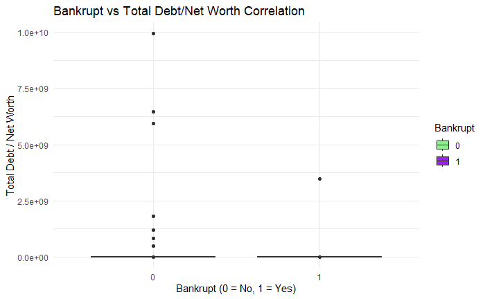

```r
ggplot(df, aes(x = as.factor(`Bankrupt?`), y = `Total debt/Total net worth`, fill = as.factor(`Bankrupt?`))) +
  geom_boxplot() +
  labs(title = "Bankrupt vs Total Debt/Net Worth Correlation",
       x = "Bankrupt (0 = No, 1 = Yes)",
       y = "Total Debt / Net Worth") +
  theme_minimal() +
  scale_fill_manual(values = c("lightgreen", "purple"), name = "Bankrupt")
```

**Interpretation:** Most companies, bankrupt or not, have a low ratio of Total Debt to Net Worth, low leverage is common in both groups. But extremely high values are more prevelant in non bankrupt companies, indicating that high leverage not necessarily results in bankruptcy.

**Bankrupt Vs. Debt Ratio %:**

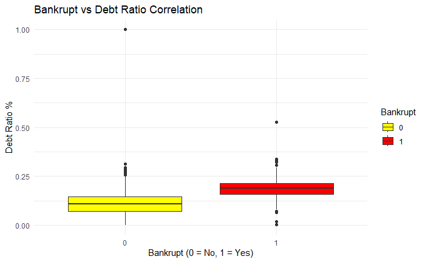

```r
ggplot(df, aes(x = as.factor(`Bankrupt?`), y = `Debt ratio %`, fill = as.factor(`Bankrupt?`))) +
  geom_boxplot() +
  labs(title = "Bankrupt vs Debt Ratio Correlation",
       x = "Bankrupt (0 = No, 1 = Yes)",
       y = "Debt Ratio %") +
  theme_minimal() +
  scale_fill_manual(values = c("yellow", "red"), name = "Bankrupt")
```

**Interpretation:** Bankrupt companies seem to have a higher debt ratio while non bankrupt generally maintain lower debt ratios.

**Bankrupt vs Net Worth/Assets:**

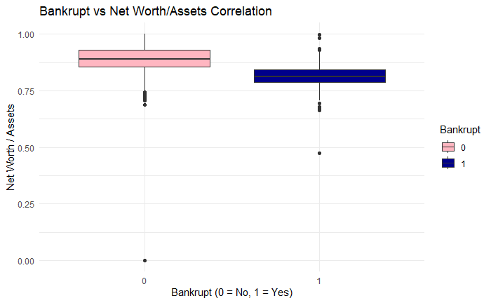

```r
ggplot(df, aes(x = as.factor(`Bankrupt?`), y = `Net worth/Assets`, fill = as.factor(`Bankrupt?`))) +
  geom_boxplot() +
  labs(title = "Bankrupt vs Net Worth/Assets Correlation",
       x = "Bankrupt (0 = No, 1 = Yes)",
       y = "Net Worth / Assets") +
  theme_minimal() +
  scale_fill_manual(values = c("lightpink", "darkblue"), name = "Bankrupt")
```

**Interpretation**: Non bankrupt companies exhibit a higher ratio,indicating stronger equity positions compared to their assets while bankrupt ones have much lowe ratios that indicate weaker solvency.

**Density Plots**

To gain a deeper understanding of how the previously examined variables behave in bankrupt companies we plot some density graphs to deeply understand the behavior.

**Net Income to Total Assets:**

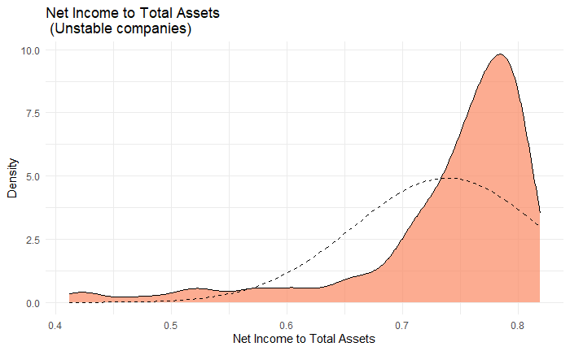

```r
ggplot(df |> filter(`Bankrupt?` == 1), aes(x = `Net Income to Total Assets`)) +
  geom_density(fill = "#FB8861", alpha = 0.7) +
  stat_function(fun = dnorm, args = list(mean = mean(df$`Net Income to Total Assets`[df$`Bankrupt?` == 1], na.rm = TRUE),
                                         sd = sd(df$`Net Income to Total Assets`[df$`Bankrupt?` == 1], na.rm = TRUE)),
                color = "black", linetype = "dashed") +
  labs(title = "Net Income to Total Assets \n (Unstable companies)",
       x = "Net Income to Total Assets",
       y = "Density") +
  theme_minimal()
```

**Interpretation:** The peak and mode seem near 0.8 and indicate that majority of bankrupt entities have a high net income compared to their total assets.

**Total Debt / Total Net Worth:**

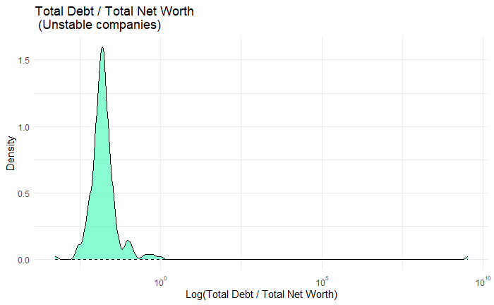

```r
ggplot(df |> filter(`Bankrupt?` == 1), aes(x = `Total debt/Total net worth`)) +
  geom_density(fill = "#56F9BB", alpha = 0.7) +
  stat_function(
    fun = dnorm,
    args = list(
      mean = mean(df$`Total debt/Total net worth`[df$`Bankrupt?` == 1], na.rm = TRUE),
      sd = sd(df$`Total debt/Total net worth`[df$`Bankrupt?` == 1], na.rm = TRUE)
    ),
    color = "black",
    linetype = "dashed"
  ) +
  scale_x_continuous(trans = "log10", breaks = scales::trans_breaks("log10", function(x) 10^x),
                     labels = scales::trans_format("log10", scales::math_format(10^.x))) +
  labs(
    title = "Total Debt / Total Net Worth \n (Unstable companies)",
    x = "Log(Total Debt / Total Net Worth)",
    y = "Density"
  ) +
  theme_minimal()
```

**Interpretation:** Used a logaritmic scale to show the distribution and it is easy to tell that is heavily skewed and most unstable companies have a low ratio.

**Debt Ratio (%)**

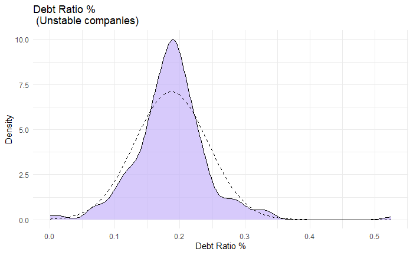

```r
ggplot(df |> filter(`Bankrupt?` == 1), aes(x = `Debt ratio %`)) +
  geom_density(fill = "#C5B3F9", alpha = 0.7) +
  stat_function(fun = dnorm, args = list(mean = mean(df$`Debt ratio %`[df$`Bankrupt?` == 1], na.rm = TRUE),
                                         sd = sd(df$`Debt ratio %`[df$`Bankrupt?` == 1], na.rm = TRUE)),
                color = "black", linetype = "dashed") +
  labs(title = "Debt Ratio % \n (Unstable companies)",
       x = "Debt Ratio %",
       y = "Density") +
  theme_minimal()
```

**Interpretation:** Most bankrupt companies exhibit a debt ratio around to 20%. There are few outiliers and this plot implies that unstable companies have moderate debt levels and that excessive debt ratios are not prevalent among these.

**Net Worth / Assets:**

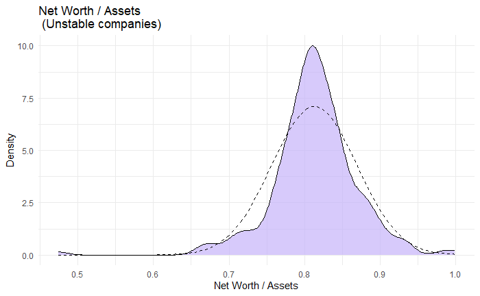

```r
ggplot(df |> filter(`Bankrupt?` == 1), aes(x = `Net worth/Assets`)) +
  geom_density(fill = "#C5B3F9", alpha = 0.7) +
  stat_function(fun = dnorm, args = list(mean = mean(df$`Net worth/Assets`[df$`Bankrupt?` == 1], na.rm = TRUE),
                                         sd = sd(df$`Net worth/Assets`[df$`Bankrupt?` == 1], na.rm = TRUE)),
                color = "black", linetype = "dashed") +
  labs(title = "Net Worth / Assets \n (Unstable companies)",
       x = "Net Worth / Assets",
       y = "Density") +
  theme_minimal()
```

**Interpretation:** Unstable companies have a significant net worth compared to their assets.

Some variables in the dataset require special treatment before applying machine learning algorithms.

### Outlier Treatment

Based on the summary statistics, we identify that *Operating Expense Rate*, *Total Debt / Total Net Worth*, *Inventory Turnover Rate*, *Fixed Assets Turnover* and *Total Asset Turnover* have extreme outliers and need to be treated. We are going to remove the outliers by cutting off values that are above the upper quantile (75th percentile) and replace them with the threshold value itself.

```r
df_clean <- df # Creating a copy of our dataset to clean it
upper_quantile_threshold <- 0.75 # Defining the threshold
variables_to_cut <- c("Operating Expense Rate",
                      "Total debt/Total net worth",
                      "Inventory Turnover Rate (times)",
                      "Fixed Assets Turnover Frequency",
                      "Total Asset Turnover")
df_clean[variables_to_cut] <- lapply(df_clean[variables_to_cut], function(column) {
  # Calculate the 75th percentile for the column
  upper_bound <- quantile(column, probs = upper_quantile_threshold, na.rm = TRUE)

  # Cap values at the 55th percentile
  column <- ifelse(column > upper_bound, upper_bound, column)
  return(column)
})
```

Checking the summary statistics to make sure the change has worked and there is no need to treat the outliers

```r
summary(df_clean[variables_to_cut])
```

```
 Operating Expense Rate Total debt/Total net worth Inventory Turnover Rate (times)
 Min.   :0.000e+00      Min.   :0.000000           Min.   :0.000e+00
 1st Qu.:0.000e+00      1st Qu.:0.003007           1st Qu.:0.000e+00
 Median :0.000e+00      Median :0.005546           Median :0.000e+00
 Mean   :1.210e+09      Mean   :0.005636           Mean   :1.459e+09
 3rd Qu.:4.142e+09      3rd Qu.:0.009271           3rd Qu.:4.620e+09
 Max.   :4.145e+09      Max.   :0.009273           Max.   :4.620e+09
 Fixed Assets Turnover Frequency Total Asset Turnover
 Min.   :0.0000000               Min.   :0.00000
 1st Qu.:0.0002330               1st Qu.:0.07646
 Median :0.0005931               Median :0.11844
 Mean   :0.0014027               Mean   :0.11750
 3rd Qu.:0.0036524               3rd Qu.:0.17691
 Max.   :0.0036524               Max.   :0.17691
```

### Logarithmic Transformation

Since we have extreme values and need to stabilize variance in order to apply machine learning models, we are going to apply logarithmic transformation (log(x+1) to reduce skewness avoiding issues with 0s in the variables *Operating Expense Rate*, *Inventory Turnover Rate*, *Fixed Assets Turnover Frequency*, *Total Asset Turnover* and *Revenue Per Share*:

```r
df_clean <- df_clean |>
  mutate(
    `Operating Expense Rate` = log1p(`Operating Expense Rate`),
    `Inventory Turnover Rate (times)` = log1p(`Inventory Turnover Rate (times)`),
    `Fixed Assets Turnover Frequency` = log1p(`Fixed Assets Turnover Frequency`),
    `Total Asset Turnover` = log1p(`Total Asset Turnover`),
    `Revenue Per Share` = log1p(`Revenue Per Share (Yuan ¥)`)
  )
```

### Scaling

In the case of extremely skewed variables, we are going to use Min-Max scaling and Z Score standardization in variables that have a more uniform distribution.

```r
variables_min_max <- c(
  "Operating Expense Rate",
  "Revenue Per Share",
  "Inventory Turnover Rate (times)",
  "Fixed Assets Turnover Frequency",
  "Total Asset Turnover"
)

df_clean <- df_clean |>
  mutate(across(all_of(variables_min_max), ~ (. - min(.)) / (max(.) - min(.))))
```

```r
variables_zscore <- c(
  "ROA(C) before interest and depreciation before interest",
  "ROA(A) before interest and % after tax",
  "ROA(B) before interest and depreciation after tax",
  "Operating Gross Margin",
  "Pre-tax net Interest Rate",
  "After-tax net Interest Rate",
  "Net Income to Total Assets"
)

# Apply z-score standardization directly to the original variables
df_clean <- df_clean |>
  mutate(across(all_of(variables_zscore), ~ (.- mean(.)) / sd(.)))
```

Checking the dataset to confirm it is scaled and ready to apply machine learning models.

```r
summary(df_clean)  # For min-max scaling
```

```
   Bankrupt?       ROA(C) before interest and depreciation before interest
 Min.   :0.00000   Min.   :-8.32453
 1st Qu.:0.00000   1st Qu.:-0.47215
 Median :0.00000   Median :-0.04077
 Mean   :0.03226   Mean   : 0.00000
 3rd Qu.:0.00000   3rd Qu.: 0.50067
 Max.   :1.00000   Max.   : 8.15383
 ROA(A) before interest and % after tax ROA(B) before interest and depreciation after tax
 Min.   :-8.51302                       Min.   :-8.98759
 1st Qu.:-0.35175                       1st Qu.:-0.42718
 Median : 0.01793                       Median :-0.02128
 Mean   : 0.00000                       Mean   : 0.00000
 3rd Qu.: 0.46529                       3rd Qu.: 0.49544
 Max.   : 6.72623                       Max.   : 7.24755
 Operating Gross Margin Realized Sales Gross Margin Operating Profit Rate
 Min.   :-35.9014       Min.   :0.0000              Min.   :0.0000
 1st Qu.: -0.4431       1st Qu.:0.6004              1st Qu.:0.9990
 Median : -0.1152       Median :0.6060              Median :0.9990
 Mean   :  0.0000       Mean   :0.6079              Mean   :0.9988
 3rd Qu.:  0.3523       3rd Qu.:0.6138              3rd Qu.:0.9991
 Max.   : 23.1520       Max.   :1.0000              Max.   :1.0000
 Pre-tax net Interest Rate After-tax net Interest Rate
 Min.   :-61.94657         Min.   :-59.48858
 1st Qu.:  0.01524         1st Qu.:  0.01676
 Median :  0.02128         Median :  0.02144
 Mean   :  0.00000         Mean   :  0.00000
 3rd Qu.:  0.03024         3rd Qu.:  0.02836
 Max.   : 15.75961         Max.   : 14.03730
 Non-industry income and expenditure/revenue Continuous interest rate (after tax)
 Min.   :0.0000                              Min.   :0.0000
 1st Qu.:0.3035                              1st Qu.:0.7816
 Median :0.3035                              Median :0.7816
 Mean   :0.3036                              Mean   :0.7814
 3rd Qu.:0.3036                              3rd Qu.:0.7817
 Max.   :1.0000                              Max.   :1.0000
 Operating Expense Rate Research and development expense rate Cash flow rate
 Min.   :0.0000000      Min.   :0.00e+00                      Min.   :0.0000
 1st Qu.:0.0000071      1st Qu.:0.00e+00                      1st Qu.:0.4616
 Median :0.0000125      Median :5.09e+08                      Median :0.4651
 Mean   :0.3302935      Mean   :1.95e+09                      Mean   :0.4674
```

[output cut: 183 more lines]

```
 Max.   :9.820e+09         Max.   :1.0000     Max.   :1.0000
 Net Income to Stockholder's Equity Liability to Equity Degree of Financial Leverage (DFL)
 Min.   :0.0000                     Min.   :0.0000      Min.   :0.00000
 1st Qu.:0.8401                     1st Qu.:0.2769      1st Qu.:0.02679
 Median :0.8412                     Median :0.2788      Median :0.02681
 Mean   :0.8404                     Mean   :0.2804      Mean   :0.02754
 3rd Qu.:0.8424                     3rd Qu.:0.2814      3rd Qu.:0.02691
 Max.   :1.0000                     Max.   :1.0000      Max.   :1.00000
 Interest Coverage Ratio (Interest expense to EBIT) Equity to Liability Revenue Per Share
 Min.   :0.0000                                     Min.   :0.00000     Min.   :0.0000000
 1st Qu.:0.5652                                     1st Qu.:0.02448     1st Qu.:0.0007106
 Median :0.5653                                     Median :0.03380     Median :0.0012373
 Mean   :0.5654                                     Mean   :0.04758     Mean   :0.0024280
 3rd Qu.:0.5657                                     3rd Qu.:0.05284     3rd Qu.:0.0020759
 Max.   :1.0000                                     Max.   :1.00000     Max.   :1.0000000
```

```r
dim(df_clean)
```

```
[1] 6819   96
```

### Treating Imbalanced Dataset

Given the proportion of bankrupt companies, we are going to use SMOTE to increase the minority class while preserving our distribution. First, renaming the target variable to avoid issues with the special characters:

```r
colnames(df_clean)[colnames(df_clean) == "Bankrupt?"] <- "Bankrupt"
```

### Machine Learning Modeling

Now we split our dataset into test and train:

```r
set.seed(42)

data_split <- initial_split(df_clean, prop = 0.7, strata = Bankrupt)

train_data <- training(data_split)
test_data <- testing(data_split)
```

Then turning the target variable into a factor:

```r
train_data <- train_data |>
  mutate(Bankrupt = as.factor(Bankrupt))

test_data <- test_data |>
  mutate(Bankrupt = as.factor(Bankrupt))
```

```r
# Recipe for applying SMOTE
smote_recipe <- recipe(Bankrupt ~ ., data = train_data) %>%
  step_smote(Bankrupt, over_ratio = 0.3 / 0.7) # Set the desired 30:70 balance

# Prepare the recipe
prepared_recipe <- prep(smote_recipe, training = train_data)

# Apply SMOTE
smote_train_data <- juice(prepared_recipe)

# Verify class balance
table(smote_train_data$Bankrupt) / nrow(smote_train_data) * 100
```

```
 0  1
70 30
```

```r
# The test data remains untouched for evaluation
test_data <- bake(prepared_recipe, new_data = test_data)
```

Now are dataset is more balanced and ready to train and test algorithms.

### Logistic Regression

We are going to start with the basic model for classification tasks. This is a simple, interpretable and effective if the relationship is close to linear. This model will be used as a baseline and see how it compares to the others we do after this.

```r
# Ensure the target variable has valid factor levels
levels(smote_train_data$Bankrupt) <- c("No", "Yes")
levels(test_data$Bankrupt) <- c("No", "Yes")

# Set up training control for cross-validation
train_control <- trainControl(
  method = "cv",        # Cross-validation
  number = 10,          # 10-fold cross-validation
  summaryFunction = twoClassSummary, # Use metrics like AUC
  classProbs = TRUE,    # Use class probabilities
  verboseIter = FALSE    # Dont display progress
)

# Fit logistic regression model
set.seed(42)
logistic_model <- suppressWarnings(
  train(
  Bankrupt ~ .,         # Formula for predictors and target
  data = smote_train_data, # Balanced training data
  method = "glm",       # Logistic regression
  family = "binomial",  # Specify logistic regression
  metric = "ROC",       # Optimize model based on ROC
  trControl = train_control # Training control setup
)
)

# Print model results
print(logistic_model)
```

```
Generalized Linear Model

6590 samples
  95 predictor
   2 classes: 'No', 'Yes'

No pre-processing
Resampling: Cross-Validated (10 fold)
Summary of sample sizes: 5931, 5932, 5931, 5932, 5930, 5931, ...
Resampling results:

  ROC        Sens       Spec
  0.9189937  0.9295415  0.8189971
```

```r
# Predict on test data
predictions <- predict(logistic_model, newdata = test_data)
probs <- predict(logistic_model, newdata = test_data, type = "prob")
# Confusion matrix
conf_matrix <- confusionMatrix(predictions, test_data$Bankrupt, positive = "Yes")
print(conf_matrix)
```

```
Confusion Matrix and Statistics

          Reference
Prediction   No  Yes
       No  1847   27
       Yes  139   33

               Accuracy : 0.9189
                 95% CI : (0.9062, 0.9303)
    No Information Rate : 0.9707
    P-Value [Acc > NIR] : 1

                  Kappa : 0.252

 Mcnemar's Test P-Value : <2e-16

            Sensitivity : 0.55000
            Specificity : 0.93001
         Pos Pred Value : 0.19186
         Neg Pred Value : 0.98559
             Prevalence : 0.02933
         Detection Rate : 0.01613
   Detection Prevalence : 0.08407
      Balanced Accuracy : 0.74001

       'Positive' Class : Yes
```

```r
# Evaluate AUC
roc_curve <- roc(test_data$Bankrupt, probs[, "Yes"], levels = rev(levels(test_data$Bankrupt)))
auc_value <- auc(roc_curve)
cat("AUC: ", auc_value, "\n")
```

```
AUC:  0.8834928
```

```r
# Additional evaluation metrics
accuracy <- conf_matrix$overall["Accuracy"]
cat("Accuracy: ", accuracy, "\n")
```

```
Accuracy:  0.9188661
```

```r
sensitivity <- conf_matrix$byClass["Sensitivity"]
cat("Sensitivity: ", sensitivity, "\n")
```

```
Sensitivity:  0.55
```

```r
specificity <- conf_matrix$byClass["Specificity"]
cat("Specificity: ", specificity, "\n")
```

```
Specificity:  0.9300101
```

```r
precision <- conf_matrix$byClass["Pos Pred Value"]
recall <- conf_matrix$byClass["Sensitivity"]
f1_score <- 2 * (precision * recall) / (precision + recall)
cat("F1-Score: ", f1_score, "\n")
```

```
F1-Score:  0.2844828
```

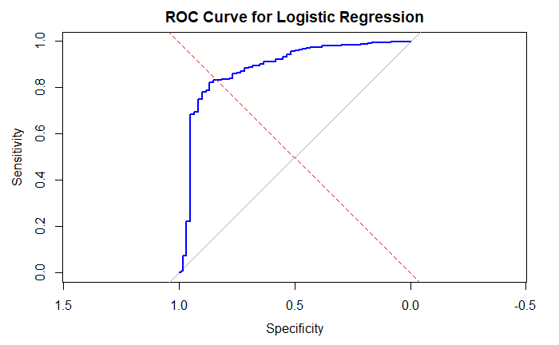

```r
# Plot ROC Curve
plot(roc_curve, main = "ROC Curve for Logistic Regression", col = "blue", lwd = 2)
abline(a = 0, b = 1, lty = 2, col = "red")
```

```r
# Save results to compare later
model_evaluation <- data.frame(
  Model = "Logistic Regression",
  Accuracy = accuracy,
  AUC = auc_value,
  Sensitivity = sensitivity,
  Specificity = specificity,
  F1_Score = f1_score
)
print(model_evaluation)
```

|  | Model | Accuracy | AUC | Sensitivity | Specificity | F1_Score |
| --- | --- | --- | --- | --- | --- | --- |
| Accuracy | Logistic Regression | 0.9188661 | 0.8834928 | 0.55 | 0.9300101 | 0.2844828 |

```r
NA
NA
```

**Logistic Regression Interpretation:**

The specificity (0.93) indicates that the model is highly capable of identifying non-bankrupt companies correctly. However, the sensitivity (0.55), reflects its lower ability to detect bankrupt companies compared to its performance in identifying non-bankrupt ones. This imbalance implies the model is better at avoiding false positives (incorrectly classifying non-bankrupt companies as bankrupt) than at capturing false negatives (missing bankrupt companies).

The F1-Score (0.28), which balances precision and recall, is relatively low. This indicates that, despite its high accuracy and specificity, the model struggles with the minority class (bankrupt companies), highlighting a challenge often encountered in imbalanced datasets.

Overall, the model performs well for general predictions but shows room for improvement, particularly in addressing class imbalance to enhance its sensitivity and F1-Score.

### Logistic Regression HyperTuned:

```r
# Define training control with cross-validation
train_control <- trainControl(
  method = "cv",             # Cross-validation
  number = 10,               # 10-fold cross-validation
  summaryFunction = twoClassSummary, # Optimize based on AUC
  classProbs = TRUE,         # Enable class probabilities
  verboseIter = FALSE         # Dont show progress
)

# Define the parameter grid for tuning (adjusted lambda range)
grid <- expand.grid(
  .alpha = c(0, 0.5, 1),    # Elastic Net mixing parameter (ridge: 0, lasso: 1, elastic net: 0.5)
  .lambda = seq(0.001, 0.05, length.out = 10) # Regularization strength (smaller range)
)

# Train the logistic regression model with hyperparameter tuning
set.seed(42)
logistic_tuned <- suppressWarnings(
  train(
  Bankrupt ~ .,               # Formula for predictors and target
  data = smote_train_data,    # Balanced training data
  method = "glmnet",          # Generalized Linear Model with Elastic Net
  metric = "ROC",             # Optimize for AUC
  tuneGrid = grid,            # Parameter grid for tuning
  trControl = train_control   # Training control setup
)
)

# Print the best model and parameters
print(logistic_tuned)
```

```
glmnet

6590 samples
  95 predictor
   2 classes: 'No', 'Yes'

No pre-processing
Resampling: Cross-Validated (10 fold)
Summary of sample sizes: 5931, 5932, 5931, 5932, 5930, 5931, ...
Resampling results across tuning parameters:

  alpha  lambda       ROC        Sens       Spec
  0.0    0.001000000  0.9564535  0.9325835  0.8219889
  0.0    0.006444444  0.9564535  0.9325835  0.8219889
  0.0    0.011888889  0.9564535  0.9325835  0.8219889
  0.0    0.017333333  0.9564535  0.9325835  0.8219889
  0.0    0.022777778  0.9564535  0.9325835  0.8219889
  0.0    0.028222222  0.9562330  0.9328000  0.8214864
  0.0    0.033666667  0.9556770  0.9334507  0.8169333
  0.0    0.039111111  0.9551747  0.9330169  0.8133877
  0.0    0.044555556  0.9547392  0.9330169  0.8103523
  0.0    0.050000000  0.9542655  0.9332333  0.8088345
  0.5    0.001000000  0.9616235  0.9334474  0.8432036
  0.5    0.006444444  0.9574377  0.9310646  0.8260216
  0.5    0.011888889  0.9552607  0.9314975  0.8275317
  0.5    0.017333333  0.9542317  0.9310655  0.8138799
  0.5    0.022777778  0.9535609  0.9321497  0.8073040
  0.5    0.028222222  0.9530424  0.9345353  0.7971953
  0.5    0.033666667  0.9526811  0.9360533  0.7896093
  0.5    0.039111111  0.9521714  0.9377877  0.7815182
  0.5    0.044555556  0.9516002  0.9397386  0.7678639
  0.5    0.050000000  0.9510422  0.9410396  0.7526970
  1.0    0.001000000  0.9615260  0.9340987  0.8381480
  1.0    0.006444444  0.9559191  0.9327985  0.8219710
  1.0    0.011888889  0.9543743  0.9345339  0.8148951
  1.0    0.017333333  0.9532176  0.9364857  0.7992283
  1.0    0.022777778  0.9519490  0.9388709  0.7805133
  1.0    0.028222222  0.9509521  0.9412565  0.7658463
  1.0    0.033666667  0.9503212  0.9429905  0.7451084
  1.0    0.039111111  0.9500121  0.9458081  0.7253807
  1.0    0.044555556  0.9496337  0.9497103  0.7021202
  1.0    0.050000000  0.9492079  0.9531801  0.6818874

ROC was used to select the optimal model using the largest value.
The final values used for the model were alpha = 0.5 and lambda = 0.001.
```

```r
# Predict on test data
predictions <- predict(logistic_tuned, newdata = test_data)
probs <- predict(logistic_tuned, newdata = test_data, type = "prob")

# Ensure that factor levels of the test data match the training levels
levels(test_data$Bankrupt) <- levels(smote_train_data$Bankrupt)

# Confusion matrix
conf_matrix <- confusionMatrix(predictions, test_data$Bankrupt, positive = "Yes")
print(conf_matrix)
```

```
Confusion Matrix and Statistics

          Reference
Prediction   No  Yes
       No  1860   24
       Yes  126   36

               Accuracy : 0.9267
                 95% CI : (0.9145, 0.9376)
    No Information Rate : 0.9707
    P-Value [Acc > NIR] : 1

                  Kappa : 0.2941

 Mcnemar's Test P-Value : <2e-16

            Sensitivity : 0.60000
            Specificity : 0.93656
         Pos Pred Value : 0.22222
         Neg Pred Value : 0.98726
             Prevalence : 0.02933
         Detection Rate : 0.01760
   Detection Prevalence : 0.07918
      Balanced Accuracy : 0.76828

       'Positive' Class : Yes
```

```r
# Evaluate AUC
roc_curve <- roc(test_data$Bankrupt, probs[, "Yes"], levels = rev(levels(test_data$Bankrupt)))
auc_value <- auc(roc_curve)
cat("AUC: ", auc_value, "\n")
```

```
AUC:  0.9153869
```

```r
# Additional metrics
accuracy <- conf_matrix$overall["Accuracy"]
cat("Accuracy: ", accuracy, "\n")
```

```
Accuracy:  0.9266862
```

```r
sensitivity <- conf_matrix$byClass["Sensitivity"]
cat("Sensitivity: ", sensitivity, "\n")
```

```
Sensitivity:  0.6
```

```r
specificity <- conf_matrix$byClass["Specificity"]
cat("Specificity: ", specificity, "\n")
```

```
Specificity:  0.9365559
```

```r
precision <- conf_matrix$byClass["Pos Pred Value"]
recall <- conf_matrix$byClass["Sensitivity"]
f1_score <- 2 * (precision * recall) / (precision + recall)
cat("F1-Score: ", f1_score, "\n")
```

```
F1-Score:  0.3243243
```

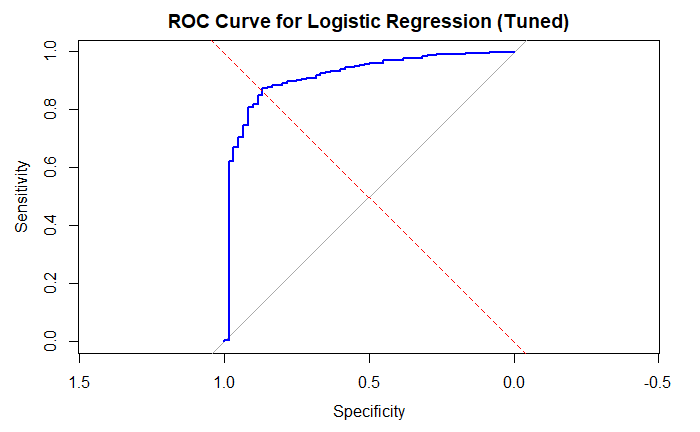

```r
# Plot ROC Curve
plot(roc_curve, main = "ROC Curve for Logistic Regression (Tuned)", col = "blue", lwd = 2)
abline(a = 0, b = 1, lty = 2, col = "red")
```

```r
# Save tuned model evaluation results
tuned_model_evaluation <- data.frame(
  Model = "Logistic Regression (Tuned)",
  Accuracy = accuracy,
  AUC = auc_value,
  Sensitivity = sensitivity,
  Specificity = specificity,
  F1_Score = f1_score
)

# Append to existing results
model_evaluation <- rbind(model_evaluation, tuned_model_evaluation)

# Print combined results
print(model_evaluation)
```

|  | Model | Accuracy | AUC | Sensitivity | Specificity | F1_Score |
| --- | --- | --- | --- | --- | --- | --- |
| Accuracy | Logistic Regression | 0.9188661 | 0.8834928 | 0.55 | 0.9300101 | 0.2844828 |
| Accuracy1 | Logistic Regression (Tuned) | 0.9266862 | 0.9153869 | 0.60 | 0.9365559 | 0.3243243 |

**Logistic Regression Tuned Interpretation:**

The tuned logistic regression model achieved an accuracy of 92.66% and an AUC of 0.91, reflecting strong overall classification performance and excellent discriminatory power. While sensitivity improved slightly to 60%, indicating a increased ability to identify bankrupt companies compared to the baseline model, specificity improved slightly to 93.65%, showing a robust capacity to correctly classify non-bankrupt cases. The F1-Score also improved to 0.32, highlighting a better balance between precision and recall, which is essential for handling the dataset’s class imbalance effectively.

### Cat Boost

```r
# Convert target variable to numeric (0 and 1) for CatBoost
smote_train_data$Bankrupt <- ifelse(smote_train_data$Bankrupt == "Yes", 1, 0)
test_data$Bankrupt <- ifelse(test_data$Bankrupt == "Yes", 1, 0)

# Convert training and testing data into CatBoost pools
train_pool <- catboost.load_pool(data = smote_train_data[, -which(colnames(smote_train_data) == "Bankrupt")],
                                 label = smote_train_data$Bankrupt)
test_pool <- catboost.load_pool(data = test_data[, -which(colnames(test_data) == "Bankrupt")],
                                label = test_data$Bankrupt)

# Train the CatBoost model using default parameters
set.seed(42)
catboost_model <- catboost.train(
  learn_pool = train_pool,
  test_pool = test_pool,
  params = list(verbose = 0) # To supress long outputs
)

# Predict probabilities on the test set
test_predictions <- catboost.predict(catboost_model, test_pool, prediction_type = "Probability")
predicted_classes <- ifelse(test_predictions > 0.5, 1, 0)

# Confusion matrix
conf_matrix <- confusionMatrix(
  factor(predicted_classes, levels = c(0, 1)),
  factor(test_data$Bankrupt, levels = c(0, 1))
)
print(conf_matrix)
```

```
Confusion Matrix and Statistics

          Reference
Prediction    0    1
         0  901    7
         1 1085   53

               Accuracy : 0.4663
                 95% CI : (0.4445, 0.4882)
    No Information Rate : 0.9707
    P-Value [Acc > NIR] : 1

                  Kappa : 0.0347

 Mcnemar's Test P-Value : <2e-16

            Sensitivity : 0.45368
            Specificity : 0.88333
         Pos Pred Value : 0.99229
         Neg Pred Value : 0.04657
             Prevalence : 0.97067
         Detection Rate : 0.44037
   Detection Prevalence : 0.44379
      Balanced Accuracy : 0.66850

       'Positive' Class : 0
```

```r
# Evaluate AUC
roc_curve <- roc(test_data$Bankrupt, test_predictions)
auc_value <- auc(roc_curve)
cat("AUC: ", auc_value, "\n")
```

```
AUC:  0.8625629
```

```r
# Additional metrics
accuracy <- conf_matrix$overall["Accuracy"]
cat("Accuracy: ", accuracy, "\n")
```

```
Accuracy:  0.4662757
```

```r
sensitivity <- conf_matrix$byClass["Sensitivity"]
cat("Sensitivity: ", sensitivity, "\n")
```

```
Sensitivity:  0.4536757
```

```r
specificity <- conf_matrix$byClass["Specificity"]
cat("Specificity: ", specificity, "\n")
```

```
Specificity:  0.8833333
```

```r
precision <- conf_matrix$byClass["Pos Pred Value"]
recall <- conf_matrix$byClass["Sensitivity"]
f1_score <- 2 * (precision * recall) / (precision + recall)
cat("F1-Score: ", f1_score, "\n")
```

```
F1-Score:  0.6226676
```

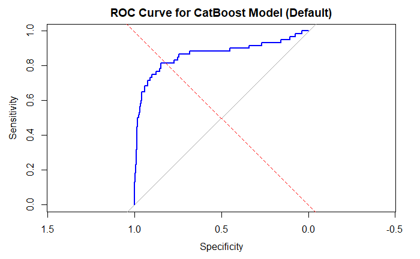

```r
# Plot ROC Curve
plot(roc_curve, main = "ROC Curve for CatBoost Model (Default)", col = "blue", lwd = 2)
abline(a = 0, b = 1, lty = 2, col = "red")
```

```r
# Save model evaluation results in the existing model_evaluation data frame
catboost_model_evaluation <- data.frame(
  Model = "CatBoost (Default)",
  Accuracy = as.numeric(accuracy),
  AUC = as.numeric(auc_value),
  Sensitivity = as.numeric(sensitivity),
  Specificity = as.numeric(specificity),
  F1_Score = as.numeric(f1_score)
)

# Append to model_evaluation
model_evaluation <- rbind(model_evaluation, catboost_model_evaluation)
print(model_evaluation)
```

|  | Model | Accuracy | AUC | Sensitivity | Specificity | F1_Score |
| --- | --- | --- | --- | --- | --- | --- |
| Accuracy | Logistic Regression | 0.9188661 | 0.8834928 | 0.5500000 | 0.9300101 | 0.2844828 |
| Accuracy1 | Logistic Regression (Tuned) | 0.9266862 | 0.9153869 | 0.6000000 | 0.9365559 | 0.3243243 |
| 1 | CatBoost (Default) | 0.4662757 | 0.8625629 | 0.4536757 | 0.8833333 | 0.6226676 |

```r
NA
```

### CatBoost HyperTuned:

```r
# Define parameter grid for hyperparameter tuning
param_grid <- expand.grid(
  depth = c(4, 6, 8),
  learning_rate = c(0.01, 0.1, 0.2),
  iterations = c(100, 300, 500)
)

# Initialize variables to store the best model and its performance
best_model <- NULL
best_auc <- 0
best_params <- NULL

# Perform grid search
for (i in 1:nrow(param_grid)) {
  params <- list(
    depth = param_grid$depth[i],
    learning_rate = param_grid$learning_rate[i],
    iterations = param_grid$iterations[i],
    loss_function = "Logloss",
    eval_metric = "AUC",
    use_best_model = TRUE,
    verbose = 0
  )

  # Train the model
  model <- catboost.train(
    train_pool,
    test_pool,
    params = params
  )

  # Evaluate the model
  predictions <- catboost.predict(model, test_pool, prediction_type = "Probability")
  auc_value <- pROC::auc(pROC::roc(test_data$Bankrupt, predictions))

  # Check if the current model is the best
  if (auc_value > best_auc) {
    best_model <- model
    best_auc <- auc_value
    best_params <- params
  }
}
# Print the best parameters
cat("Best Parameters: \n")
```

```
Best Parameters:
```

```r
print(best_params)
```

```
$depth
[1] 8

$learning_rate
[1] 0.01

$iterations
[1] 500

$loss_function
[1] "Logloss"

$eval_metric
[1] "AUC"

$use_best_model
[1] TRUE

$verbose
[1] 0
```

```r
# Evaluate the best model on the test set
final_predictions <- catboost.predict(best_model, test_pool, prediction_type = "Probability")
roc_curve <- pROC::roc(test_data$Bankrupt, final_predictions)
final_auc <- pROC::auc(roc_curve)

cat("Final AUC: ", final_auc, "\n")
```

```
Final AUC:  0.9387798
```

```r
# Confusion matrix
final_predictions_binary <- ifelse(final_predictions > 0.5, 1, 0)
conf_matrix <- caret::confusionMatrix(
  factor(final_predictions_binary, levels = c(0, 1)),
  factor(test_data$Bankrupt, levels = c(0, 1))
)

print(conf_matrix)
```

```
Confusion Matrix and Statistics

          Reference
Prediction    0    1
         0 1940   29
         1   46   31

               Accuracy : 0.9633
                 95% CI : (0.9543, 0.9711)
    No Information Rate : 0.9707
    P-Value [Acc > NIR] : 0.97581

                  Kappa : 0.4339

 Mcnemar's Test P-Value : 0.06467

            Sensitivity : 0.9768
            Specificity : 0.5167
         Pos Pred Value : 0.9853
         Neg Pred Value : 0.4026
             Prevalence : 0.9707
         Detection Rate : 0.9482
   Detection Prevalence : 0.9624
      Balanced Accuracy : 0.7468

       'Positive' Class : 0
```

```r
# Calculate evaluation metrics
accuracy <- conf_matrix$overall["Accuracy"]
sensitivity <- conf_matrix$byClass["Sensitivity"]
specificity <- conf_matrix$byClass["Specificity"]
precision <- conf_matrix$byClass["Pos Pred Value"]
recall <- conf_matrix$byClass["Sensitivity"]
f1_score <- 2 * (precision * recall) / (precision + recall)

# Save model evaluation results
catboost_tuned_evaluation <- data.frame(
  Model = "CatBoost (Tuned)",
  Accuracy = accuracy,
  AUC = final_auc,
  Sensitivity = sensitivity,
  Specificity = specificity,
  F1_Score = f1_score
)

# Combine with previous model evaluation results
model_evaluation <- rbind(model_evaluation, catboost_tuned_evaluation)
print(model_evaluation)
```

|  | Model | Accuracy | AUC | Sensitivity | Specificity | F1_Score |
| --- | --- | --- | --- | --- | --- | --- |
| Accuracy | Logistic Regression | 0.9188661 | 0.8834928 | 0.5500000 | 0.9300101 | 0.2844828 |
| Accuracy1 | Logistic Regression (Tuned) | 0.9266862 | 0.9153869 | 0.6000000 | 0.9365559 | 0.3243243 |
| 1 | CatBoost (Default) | 0.4662757 | 0.8625629 | 0.4536757 | 0.8833333 | 0.6226676 |
| Accuracy2 | CatBoost (Tuned) | 0.9633431 | 0.9387798 | 0.9768379 | 0.5166667 | 0.9810367 |

```r
NA
```

Displaying the parameters of the best model:

```r
# Display the parameters of the best model
# Store best parameters during tuning
best_params_list <- list(
  depth = best_params$depth,
  learning_rate = best_params$learning_rate,
  iterations = best_params$iterations,
  loss_function = best_params$loss_function,
  eval_metric = best_params$eval_metric
)

# Print best parameters
cat("Best Hyperparameters:\n")
```

```
Best Hyperparameters:
```

```r
print(best_params)
```

```
$depth
[1] 8

$learning_rate
[1] 0.01

$iterations
[1] 500

$loss_function
[1] "Logloss"

$eval_metric
[1] "AUC"

$use_best_model
[1] TRUE

$verbose
[1] 0
```

### Feature Importance:

```r
# Get feature importance
feature_importance <- catboost.get_feature_importance(best_model,
                                                      pool = train_pool,
                                                      type = "FeatureImportance")

# Convert to a data frame for easier manipulation
feature_importance_df <- data.frame(
  Feature = colnames(smote_train_data[, -which(colnames(smote_train_data) == "Bankrupt")]),
  Importance = feature_importance
)

# Sort by importance in descending order
feature_importance_df <- feature_importance_df[order(-feature_importance_df$Importance), ]

# Print the top features
print(head(feature_importance_df, 15))
```

|  | Feature | Importance |
| --- | --- | --- |
| Inventory Turnover Rate (times) | Inventory Turnover Rate (times) | 6.182275 |
| Fixed Assets Turnover Frequency | Fixed Assets Turnover Frequency | 5.638595 |
| Borrowing dependency | Borrowing dependency | 4.383993 |
| Operating Expense Rate | Operating Expense Rate | 4.135809 |
| Interest-bearing debt interest rate | Interest-bearing debt interest rate | 3.921203 |
| Research and development expense rate | Research and development expense rate | 3.466443 |
| Allocation rate per person | Allocation rate per person | 3.403800 |
| Revenue per person | Revenue per person | 3.336404 |
| Non-industry income and expenditure/revenue | Non-industry income and expenditure/revenue | 3.259304 |
| Continuous interest rate (after tax) | Continuous interest rate (after tax) | 3.141961 |

[output cut: 5 more lines]

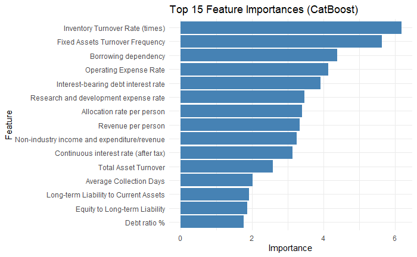

```r
# Select top 15 features
top_15_features <- feature_importance_df %>%
  arrange(desc(Importance)) %>%
  slice(1:15)

# Plot top 15 features
library(ggplot2)
ggplot(top_15_features, aes(x = reorder(Feature, Importance), y = Importance)) +
  geom_bar(stat = "identity", fill = "steelblue") +
  coord_flip() +
  labs(
    title = "Top 15 Feature Importances (CatBoost)",
    x = "Feature",
    y = "Importance"
  ) +
  theme_minimal()
```

### Conclusion

Steps to Follow: To further improve the modeling and obtain a stronger solution ready to deploy we could do the following:

- Comparing results with other ensemble models like XGBoost or LightGBM. SVM could also be applied to this dataset.
- Feature selection techniques to streamline the input dataset, potentially reducing computation time and improving interpretability.
- Deployment strategies for integrating the predictive model into decision-making workflows, particularly for financial institutions.

**Disclaimer:** ChatGPT was used as a support tool in this project mainly for troubleshooting, debugging, understanding syntax and refining code implementations. Additionally, ChatGPT provided suggestions for improving code structure, ensuring adherence to best practices in R programming, and optimizing model evaluation workflows.